# Assignment 3

The tasks of this assignment are to implement the SVM algorithm on three different datasets. Investigate the classification results when using different kernels, and the impact of hyperparameters on model evaluation.

## Task 0

Before starting, we need to import the relevant packages and set the random seed.

```python
import numpy as np
import pandas as pd
import matplotlib.pyplot as plt
from sklearn.svm import SVC
from sklearn.datasets import make_blobs
from sklearn.model_selection import KFold
from sklearn.model_selection import LeaveOneOut
from sklearn.model_selection import GridSearchCV
```

```python
# Reload local python files every 2 seconds
%load_ext autoreload
%autoreload 2
```

```python
RANDOM_STATE = 1234
np.random.seed(RANDOM_STATE)
```

## Task 1

In this task, we need to design a dataset, train the SVM model with a linear kernel, and evaluate the model with a leave-one-out CV. In addition, improve the SVM by changing the hyperparameter C, and investigating the effect of C on the SVM.

### 1.1 Design a dataset

We used 'make_blobs' to generate the dataset, setting the total number of samples to 100 to ensure that each class contains 50 points. By adjusting 'cluster_std', the data points in the two classes are partly crossed, that is, there is no clear 'boundary'.

```python
# Generate dataset
data, label = make_blobs(n_samples=100, n_features=2, centers=2, cluster_std=5.0, random_state=RANDOM_STATE)
```

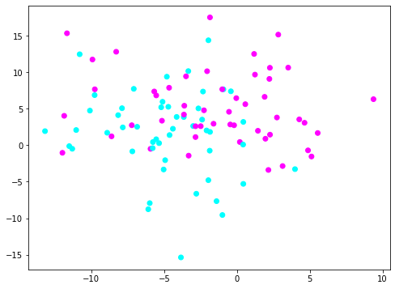

```python
# Preview the distribution of the dataset
plt.figure(figsize=(8,6))
plt.scatter(data[:, 0], data[:, 1], c=label, cmap='cool')
plt.show()
```

```python
# Output the dataset as a 'csv' file
output = pd.DataFrame(data=data, columns=['x1', 'x2'])
output['class'] = label
output.to_csv('D1.csv', index=False)
```

### 1.2 Load the dataset and train the model

We load the dataset 'D1' generated in the previous step and train the SVM model on the full dataset. In this step, we only use the 'linear' kernel and keep other parameters as default.

```python
# Load the dataset and preview the first 5 rows
ds_1=pd.read_csv('D1.csv')
ds_1.head()
```

|  | x1 | x2 | class |
| --- | --- | --- | --- |
| 0 | -8.292604 | 12.822101 | 1 |
| 1 | -0.419432 | 7.401906 | 0 |
| 2 | -1.402990 | -7.664099 | 0 |
| 3 | -1.854087 | 17.536015 | 1 |
| 4 | -3.499271 | 9.452991 | 1 |

```python
# Split features and class
x = ds_1.drop(['class'],axis=1).to_numpy()
y = ds_1['class'].to_numpy()
print(x.shape, y.shape)
```

```
(100, 2) (100,)
```

```python
# Training model
clf_1 = SVC(C=1.0, kernel='linear', gamma='scale', random_state=RANDOM_STATE)
clf_1.fit(x, y)
```

```
SVC(kernel='linear', random_state=1234)
```

```python
# define a function for plotting decision boundary
def decision_boundary(clf, ax=None):
    if ax is None:
        ax = plt.gca()
    xlim = ax.get_xlim()
    ylim = ax.get_ylim()
    x_point = np.linspace(xlim[0], xlim[1], 50)
    y_point = np.linspace(ylim[0], ylim[1], 50)
    X, Y = np.meshgrid(x_point, y_point)
    xy = np.vstack([X.ravel(), Y.ravel()]).T
    P = clf.decision_function(xy).reshape(X.shape)
    ax.contour(X, Y, P, colors=['k', 'r', 'k'], levels=[-1, 0, 1], alpha=0.5, linestyles=['--', '-', '--'])
    ax.set_xlim(xlim)
    ax.set_ylim(ylim)
    plt.show()
```

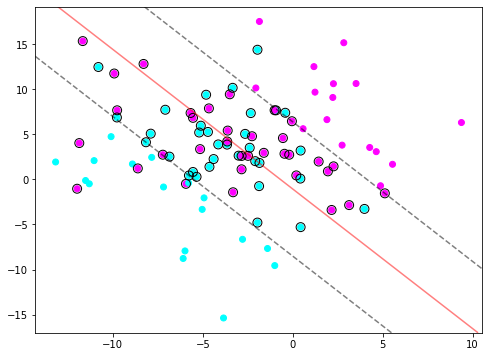

```python
# Visualization
plt.figure(figsize=(8,6))
# plot dataset
plt.scatter(x[:, 0], x[:, 1], c=y, cmap='cool')
# plot support vectors
plt.scatter(clf_1.support_vectors_[:, 0], clf_1.support_vectors_[:, 1], edgecolor='k', s=80, facecolors='none')
#plot decision boundary
decision_boundary(clf_1)
```

### 1.3 Leave-One-Out CV

Leave-one-out CV is a special case of k-fold cross-validation, where k = number of samples. The advantage is that we train with almost all the data and test with the remaining one, the result is deterministic. But its disadvantage is that it consumes a lot of computing time, so it is more suitable for situations with a small amount of data.

```python
x = ds_1.drop(['class'],axis=1).to_numpy()
y = ds_1['class'].to_numpy()
```

```python
# Create list to store the results of each evaluation
scoreList_train = []
scoreList_test = []

loo = LeaveOneOut()
for train_index, test_index in loo.split(x):
    x_train, x_test = x[train_index], x[test_index]
    y_train, y_test = y[train_index], y[test_index]

    # Train the model
    clf_loo = SVC(C=1.0, kernel='linear', gamma='scale', random_state=RANDOM_STATE)
    clf_loo.fit(x_train, y_train)

    # Evaluate the model
    score_train = clf_loo.score(x_train, y_train)
    scoreList_train.append(score_train)

    score_test = clf_loo.score(x_test, y_test)
    scoreList_test.append(score_test)

print('Mean accuracy on the training set: {:.2f}%'.format(np.mean(scoreList_train)*100))
print('Mean accuracy on the testing set: {:.2f}%'.format(np.mean(scoreList_test)*100))
```

```
Mean accuracy on the training set: 72.59%
Mean accuracy on the testing set: 70.00%
```

### 1.4 Improve the SVM by changing C

In this step, we will tune the value of C and observe its effect on the SVM. We use 'for' loop to dynamically tune C and plot its changing curve to observe the effect of C on model accuracy.

Since the value range of C is very large, in order to reduce the amount of calculation, we divide the value of C into 6 sub-intervals, and then observe the relationship between the value of C and the accuracy in each interval.

```python
x = ds_1.drop(['class'],axis=1).to_numpy()
y = ds_1['class'].to_numpy()
```

#### 1.4.1 C in range (0.0001 ~ 0.01)

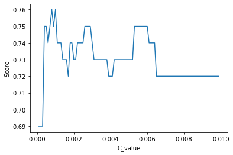

```python
C_value = np.arange(0.0001, 0.01, 0.0001)
scoreList = []
for i in C_value:
    clf_c = SVC(C=i, kernel='linear', gamma='scale', random_state=RANDOM_STATE)
    clf_c.fit(x, y)
    score = clf_c.score(x, y)
    scoreList.append(score)

plt.figure(figsize=(6,4))
plt.plot(C_value, scoreList)
plt.xlabel('C_value')
plt.ylabel('Score')
plt.show()
```

#### 1.4.2 C in range (0.01 ~ 1)

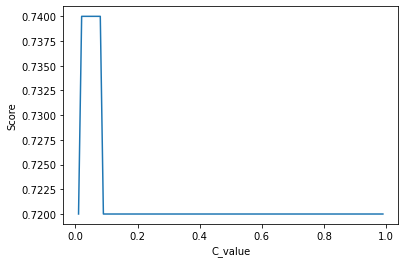

```python
C_value = np.arange(0.01, 1, 0.01)
scoreList = []
for i in C_value:
    clf_c = SVC(C=i, kernel='linear', gamma='scale', random_state=RANDOM_STATE)
    clf_c.fit(x, y)
    score = clf_c.score(x, y)
    scoreList.append(score)

plt.figure(figsize=(6,4))
plt.plot(C_value, scoreList)
plt.xlabel('C_value')
plt.ylabel('Score')
plt.show()
```

#### 1.4.3 C in range (1 ~ 100)

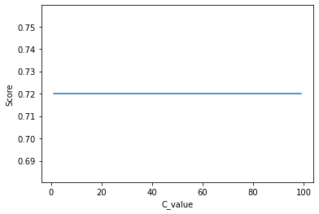

```python
C_value = np.arange(1, 100, 1)
scoreList = []
for i in C_value:
    clf_c = SVC(C=i, kernel='linear', gamma='scale', random_state=RANDOM_STATE)
    clf_c.fit(x, y)
    score = clf_c.score(x, y)
    scoreList.append(score)

plt.figure(figsize=(6,4))
plt.plot(C_value, scoreList)
plt.xlabel('C_value')
plt.ylabel('Score')
plt.show()
```

#### 1.4.4 C in range (100 ~ 1000)

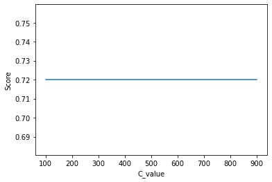

```python
C_value = np.arange(100, 1000, 100)
scoreList = []
for i in C_value:
    clf_c = SVC(C=i, kernel='linear', gamma='scale', random_state=RANDOM_STATE)
    clf_c.fit(x, y)
    score = clf_c.score(x, y)
    scoreList.append(score)

plt.figure(figsize=(6,4))
plt.plot(C_value, scoreList)
plt.xlabel('C_value')
plt.ylabel('Score')
plt.show()
```

#### 1.4.5 C in range (1000 ~ 10000)

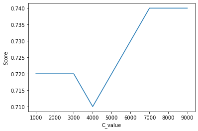

```python
C_value = np.arange(1000, 10000, 1000)
scoreList = []
for i in C_value:
    clf_c = SVC(C=i, kernel='linear', gamma='scale', random_state=RANDOM_STATE)
    clf_c.fit(x, y)
    score = clf_c.score(x, y)
    scoreList.append(score)

plt.figure(figsize=(6,4))
plt.plot(C_value, scoreList)
plt.xlabel('C_value')
plt.ylabel('Score')
plt.show()
```

#### 1.4.6 C in range (10000 ~ 100000)

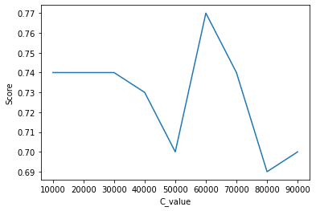

```python
C_value = np.arange(10000, 100000, 10000)
scoreList = []
for i in C_value:
    clf_c = SVC(C=i, kernel='linear', gamma='scale', random_state=RANDOM_STATE)
    clf_c.fit(x, y)
    score = clf_c.score(x, y)
    scoreList.append(score)

plt.figure(figsize=(6,4))
plt.plot(C_value, scoreList)
plt.xlabel('C_value')
plt.ylabel('Score')
plt.show()
```

#### 1.4.7 Verify the model accuracy with the changed C value

It can be observed from the above experiments that when C=0.001, the model accuracy is 0.76, and when C=60000, the model accuracy is 0.77. We bring the above two C values into the model and use the 10-fold CV to verify the accuracy again.

*Note: When the C value is large, the computational time cost increases dramatically. Due to the limitation of personal computer performance, when C=60000, we try to verify using the leave-one-out CV, but the code runs for more than 30 minutes. Therefore, it was temporarily changed to 10-fold cross-validation. In subsequent chapters, there will be a detailed explanation of the 10-fold cross-validation.*

##### 1.4.7.1 When C=0.001

```python
x = ds_1.drop(['class'],axis=1).to_numpy()
y = ds_1['class'].to_numpy()
```

```python
# Create list to store the results of each evaluation
scoreList_train = []
scoreList_test = []

# loo = LeaveOneOut()
kf = KFold(n_splits=10, random_state=RANDOM_STATE, shuffle=True)
for train_index, test_index in kf.split(x):
    x_train, x_test = x[train_index], x[test_index]
    y_train, y_test = y[train_index], y[test_index]

    # Train the model
    clf_kfc = SVC(C=0.001, kernel='linear', gamma='scale', random_state=RANDOM_STATE)
    clf_kfc.fit(x_train, y_train)

    # Evaluate the model
    score_train = clf_kfc.score(x_train, y_train)
    scoreList_train.append(score_train)

    score_test = clf_kfc.score(x_test, y_test)
    scoreList_test.append(score_test)

print('Mean accuracy on the training set: {:.2f}%'.format(np.mean(scoreList_train)*100))
print('Mean accuracy on the testing set: {:.2f}%'.format(np.mean(scoreList_test)*100))
```

```
Mean accuracy on the training set: 71.89%
Mean accuracy on the testing set: 67.00%
```

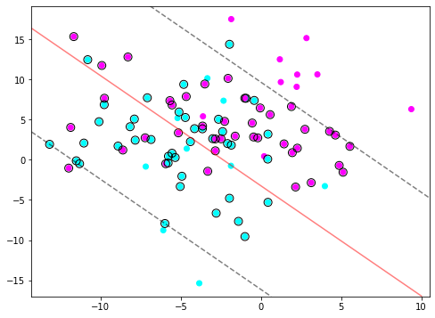

```python
# Visualization
plt.figure(figsize=(8,6))
# plot dataset
plt.scatter(x[:, 0], x[:, 1], c=y, cmap='cool')
# plot support vectors
plt.scatter(clf_kfc.support_vectors_[:, 0], clf_kfc.support_vectors_[:, 1], edgecolor='k', s=80, facecolors='none')
#plot decision boundary
decision_boundary(clf_kfc)
```

##### 1.4.7.2 When C=60000

```python
x = ds_1.drop(['class'],axis=1).to_numpy()
y = ds_1['class'].to_numpy()
```

```python
# Create list to store the results of each evaluation
scoreList_train = []
scoreList_test = []

# loo = LeaveOneOut()
kf = KFold(n_splits=10, random_state=RANDOM_STATE, shuffle=True)
for train_index, test_index in kf.split(x):
    x_train, x_test = x[train_index], x[test_index]
    y_train, y_test = y[train_index], y[test_index]

    # Train the model
    clf_kfc = SVC(C=60000, kernel='linear', gamma='scale', random_state=RANDOM_STATE)
    clf_kfc.fit(x_train, y_train)

    # Evaluate the model
    score_train = clf_kfc.score(x_train, y_train)
    scoreList_train.append(score_train)

    score_test = clf_kfc.score(x_test, y_test)
    scoreList_test.append(score_test)

print('Mean accuracy on the training set: {:.2f}%'.format(np.mean(scoreList_train)*100))
print('Mean accuracy on the testing set: {:.2f}%'.format(np.mean(scoreList_test)*100))
```

```
Mean accuracy on the training set: 71.78%
Mean accuracy on the testing set: 70.00%
```

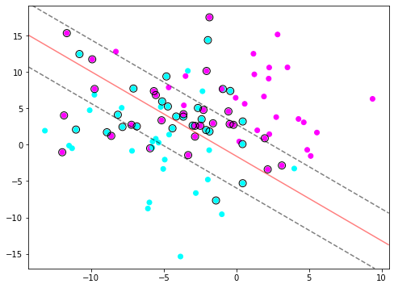

```python
# Visualization
plt.figure(figsize=(8,6))
# plot dataset
plt.scatter(x[:, 0], x[:, 1], c=y, cmap='cool')
# plot support vectors
plt.scatter(clf_kfc.support_vectors_[:, 0], clf_kfc.support_vectors_[:, 1], edgecolor='k', s=80, facecolors='none')
#plot decision boundary
decision_boundary(clf_kfc)
```

### 1.5 Summary and Explanation

C is the complexity parameter, which is also called the penalty parameter in some textbooks.

When C is larger, i.e., the tolerance for outliers in the margin is lower, and the model tends to classify the dataset as correctly as possible, so the generalization ability of the model is worse. When C tends to infinity, we get a hard-margin SVM.

When C is smaller, i.e., the tolerance for outliers in the margin is higher, and the model allows misclassification errors, so the generalization ability of the model is better. We call it soft-margin SVM.

If we compare the above two decision boundary results (C=0.001 and C=60000) with the decision boundary result from chapter 1.2 (C=1.0) we find that:

When C becomes larger, the margin (that is, the two dashed lines in the figure) becomes narrower, because the model at this time cannot allow too many outliers.

Conversely, when C becomes smaller, the margin becomes wider, which contains more outliers from both classes.

When C=0.001, the CV results show that compared with C=1, the model accuracy is reduced, because the model has a high tolerance for misclassification, the margin becomes very wide, a large number of data points are also in the margin, and a large part of this data is discarded as noise.

When C=60000, the CV results show that compared with C=1, the model accuracy does not improve much, although the margin becomes narrow, it does not change too much, and outliers in the margin are also discarded as noise.

In conclusion, we cannot simply say that the smaller the C is better or the larger the better. C does affect the accuracy of the model, but the distribution of data points is also an important factor. In practice, we need to adjust the value of C based on the distribution of the data and what kind of results we want to achieve.

## Task 2

### 2.1 Repeat step 1.2 and 1.3

#### 2.1.1 Load the dataset and train the model

We load the dataset 'D2' and train the SVM model on the full dataset. In this step, we only use the 'linear' kernel and keep other parameters as default.

```python
# Load the dataset and preview the first 5 rows
ds_2=pd.read_csv('D2.csv', header=None, names=['x1', 'x2', 'class'])
ds_2.head()
```

|  | x1 | x2 | class |
| --- | --- | --- | --- |
| 0 | 0.729263 | 0.889620 | 1 |
| 1 | 0.736175 | 0.644006 | -1 |
| 2 | 0.160138 | 0.777047 | 1 |
| 3 | 0.632488 | 0.915936 | 1 |
| 4 | 0.192396 | 0.540497 | 1 |

```python
# Check for null values
ds_2.info()
```

```
<class 'pandas.core.frame.DataFrame'>
RangeIndex: 500 entries, 0 to 499
Data columns (total 3 columns):
 #   Column  Non-Null Count  Dtype
---  ------  --------------  -----
 0   x1      500 non-null    float64
 1   x2      500 non-null    float64
 2   class   500 non-null    int64
dtypes: float64(2), int64(1)
memory usage: 11.8 KB
```

```python
# Split features and class
x = ds_2.drop(['class'],axis=1).to_numpy()
y = ds_2['class'].to_numpy()
print(x.shape, y.shape)
```

```
(500, 2) (500,)
```

```python
# Training model
clf_2 = SVC(C=1.0, kernel='linear', gamma='scale', random_state=RANDOM_STATE)
clf_2.fit(x, y)
```

```
SVC(kernel='linear', random_state=1234)
```

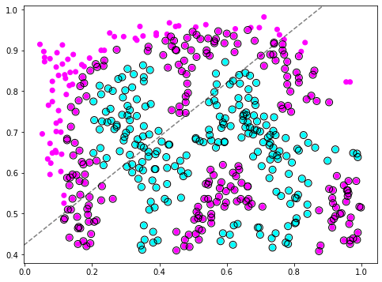

```python
# Visualization
plt.figure(figsize=(8,6))
# plot dataset
plt.scatter(x[:, 0], x[:, 1], c=y, cmap='cool')
# plot support vectors
plt.scatter(clf_2.support_vectors_[:, 0], clf_2.support_vectors_[:, 1], edgecolor='k', s=80, facecolors='none')
#plot decision boundary
decision_boundary(clf_2)
```

Obviously, it can be observed from the figure that the distribution of the dataset is not linear, we cannot plot the correct decision boundary based on the linear kernel. We will explore solutions in subsequent steps.

#### 2.1.2 Model evaluation

In this step, we will use two verification methods: Leave-One-Out CV and 10-fold CV, and compare their advantages and disadvantages. About the description of Leave-One-Out CV, please refer to chapter 1.3.

##### 2.1.2.1 Leave-One-Out CV

```python
x = ds_2.drop(['class'],axis=1).to_numpy()
y = ds_2['class'].to_numpy()
```

```python
# Create list to store the results of each evaluation
scoreList_train = []
scoreList_test = []

loo = LeaveOneOut()
for train_index, test_index in loo.split(x):
    x_train, x_test = x[train_index], x[test_index]
    y_train, y_test = y[train_index], y[test_index]

    # Train the model
    clf_loo = SVC(C=1.0, kernel='linear', gamma='scale', random_state=RANDOM_STATE)
    clf_loo.fit(x_train, y_train)

    # Evaluate the model
    score_train = clf_loo.score(x_train, y_train)
    scoreList_train.append(score_train)

    score_test = clf_loo.score(x_test, y_test)
    scoreList_test.append(score_test)

print('Mean accuracy on the training set: {:.2f}%'.format(np.mean(scoreList_train)*100))
print('Mean accuracy on the testing set: {:.2f}%'.format(np.mean(scoreList_test)*100))
```

```
Mean accuracy on the training set: 57.40%
Mean accuracy on the testing set: 57.40%
```

##### 2.1.2.2 10-fold CV

```python
x = ds_2.drop(['class'],axis=1).to_numpy()
y = ds_2['class'].to_numpy()
```

```python
# Create list to store the results of each evaluation
scoreList_train = []
scoreList_test = []

kf = KFold(n_splits=10, random_state=RANDOM_STATE, shuffle=True)
for train_index, test_index in kf.split(x):
    x_train, x_test = x[train_index], x[test_index]
    y_train, y_test = y[train_index], y[test_index]

    # Train the model
    clf_kf = SVC(C=1.0, kernel='linear', gamma='scale', random_state=RANDOM_STATE)
    clf_kf.fit(x_train, y_train)

    # Evaluate the model
    score_train = clf_kf.score(x_train, y_train)
    scoreList_train.append(score_train)

    score_test = clf_kf.score(x_test, y_test)
    scoreList_test.append(score_test)

print('Mean accuracy on the training set: {:.2f}%'.format(np.mean(scoreList_train)*100))
print('Mean accuracy on the testing set: {:.2f}%'.format(np.mean(scoreList_test)*100))
```

```
Mean accuracy on the training set: 57.40%
Mean accuracy on the testing set: 57.40%
```

##### 2.1.2.3 Summary and Explanation

The principle of 10-fold cross-validation is to randomly divide the data set into 10 parts, of which 9 are used as training set and 1 is used as testing set, and the process is repeated 10 times, so the training data and testing data used are different each time.

The leave-one-out CV is a special kind of k-fold cross-validation, where k = the number of samples.

The advantage of the leave-one-out CV is that its evaluation results are highly deterministic, but it consumes a lot of time.

The traditional 80/20 split method consumes the least time, but the results obtained may be based on coincidence.

10-fold cross-validation finds a balance between the two methods. Although it is not as deterministic as the leave-one-out CV, it saves time, especially when the amount of data is large, it has obvious advantages in speed. Compared with the 80/20 split method, the evaluation results of 10-fold cross-validation are more reliable.

For the 'D2' dataset, since it has a total of 500 data, 10-fold cross-validation is more suitable.

From the above results, it can be observed that the evaluation results of 10-fold CV are close to the evaluation results of leave-one-out CV.

### 2.2 Pick a new kernel

In this step, we will select the 'rbf' kernel and the 'poly' kernel respectively to fit the SVM model and use 10-fold CV to evaluate their performance. We only change different kernels, other parameters keep the default.

#### 2.2.1 'rbf' kernel

```python
x = ds_2.drop(['class'],axis=1).to_numpy()
y = ds_2['class'].to_numpy()
```

```python
# Training model
clf_2rbf = SVC(C=1.0, kernel='rbf', gamma='scale', random_state=RANDOM_STATE)
clf_2rbf.fit(x, y)
```

```
SVC(random_state=1234)
```

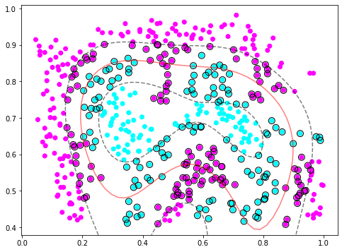

```python
# Visualization
plt.figure(figsize=(8,6))
# plot dataset
plt.scatter(x[:, 0], x[:, 1], c=y, cmap='cool')
# plot support vectors
plt.scatter(clf_2rbf.support_vectors_[:, 0], clf_2rbf.support_vectors_[:, 1], edgecolor='k', s=80, facecolors='none')
#plot decision boundary
decision_boundary(clf_2rbf)
```

```python
# Create list to store the results of each evaluation
scoreList_train = []
scoreList_test = []

kf = KFold(n_splits=10, random_state=RANDOM_STATE, shuffle=True)
for train_index, test_index in kf.split(x):
    x_train, x_test = x[train_index], x[test_index]
    y_train, y_test = y[train_index], y[test_index]

    # Train the model
    clf_rbf_kf = SVC(C=1.0, kernel='rbf', gamma='scale', random_state=RANDOM_STATE)
    clf_rbf_kf.fit(x_train, y_train)

    # Evaluate the model
    score_train = clf_rbf_kf.score(x_train, y_train)
    scoreList_train.append(score_train)

    score_test = clf_rbf_kf.score(x_test, y_test)
    scoreList_test.append(score_test)

print('Mean accuracy on the training set: {:.2f}%'.format(np.mean(scoreList_train)*100))
print('Mean accuracy on the testing set: {:.2f}%'.format(np.mean(scoreList_test)*100))
```

```
Mean accuracy on the training set: 86.40%
Mean accuracy on the testing set: 86.00%
```

#### 2.2.2 'poly' kernel

```python
x = ds_2.drop(['class'],axis=1).to_numpy()
y = ds_2['class'].to_numpy()
```

```python
# Training model
clf_2poly = SVC(C=1.0, kernel='poly', gamma='scale', random_state=RANDOM_STATE)
clf_2poly.fit(x, y)
```

```
SVC(kernel='poly', random_state=1234)
```

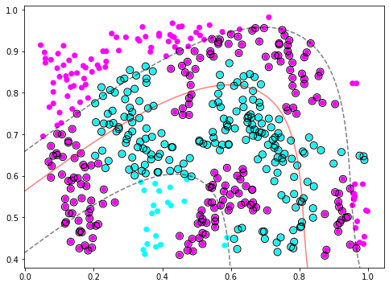

```python
# Visualization
plt.figure(figsize=(8,6))
# plot dataset
plt.scatter(x[:, 0], x[:, 1], c=y, cmap='cool')
# plot support vectors
plt.scatter(clf_2poly.support_vectors_[:, 0], clf_2poly.support_vectors_[:, 1], edgecolor='k', s=80, facecolors='none')
#plot decision boundary
decision_boundary(clf_2poly)
```

```python
# Create list to store the results of each evaluation
scoreList_train = []
scoreList_test = []

kf = KFold(n_splits=10, random_state=RANDOM_STATE, shuffle=True)
for train_index, test_index in kf.split(x):
    x_train, x_test = x[train_index], x[test_index]
    y_train, y_test = y[train_index], y[test_index]

    # Train the model
    clf_poly_kf = SVC(C=1.0, kernel='poly', gamma='scale', random_state=RANDOM_STATE)
    clf_poly_kf.fit(x_train, y_train)

    # Evaluate the model
    score_train = clf_poly_kf.score(x_train, y_train)
    scoreList_train.append(score_train)

    score_test = clf_poly_kf.score(x_test, y_test)
    scoreList_test.append(score_test)

print('Mean accuracy on the training set: {:.2f}%'.format(np.mean(scoreList_train)*100))
print('Mean accuracy on the testing set: {:.2f}%'.format(np.mean(scoreList_test)*100))
```

```
Mean accuracy on the training set: 68.67%
Mean accuracy on the testing set: 68.40%
```

### 2.3 Summary and Explanation

It can be observed from the above experimental results that whether the 'rbf' kernel or the 'poly' kernel is selected, the performance of their models is much better than that of the linear kernel model, and the performance of the 'rbf' kernel is even better. It can also be observed from the generated decision boundary figure that the decision boundary (i.e. the red line in the figure) of the 'rbf' kernel model classifies the data more perfectly than the 'poly' kernel model.

The 'rbf' kernel is also called a Gaussian kernel in some textbooks. Its principle is to map data that are non-splittable in a low-dimensional space to a high-dimensional space and then find a hyperplane to classify the data. In this experiment, the points of the 'D2' dataset are distributed in a ring shape, so in the 2D plane, it is difficult for us to find a 'line' to classify, when the 'rbf' kernel function is used, the points in the 2D plane are mapping to 3D space, in higher dimensions we can easily find a hyperplane to split the data. Therefore, in daily applications, when we are not sure whether the data is linearly distributed, the 'rbf' kernel becomes the first choice.

## Task 3

### 3.1 Repeat step 1.2 and 1.3

#### 3.1.1 Load the dataset and train the model

We load the dataset 'D3' and train the SVM model on the full dataset. In this step, we only use the 'linear' kernel and keep other parameters as default.

```python
# Load the dataset and preview the first 5 rows
ds_3=pd.read_csv('D3.csv', header=None, names=['x1', 'x2', 'class'])
ds_3.head()
```

|  | x1 | x2 | class |
| --- | --- | --- | --- |
| 0 | -0.983270 | 0.230644 | 1 |
| 1 | 1.110502 | 0.449004 | 1 |
| 2 | -1.347385 | 0.840500 | 0 |
| 3 | 0.087080 | 1.676546 | 0 |
| 4 | -1.539548 | -0.106364 | 0 |

```python
# Check for null values
ds_3.info()
```

```
<class 'pandas.core.frame.DataFrame'>
RangeIndex: 200 entries, 0 to 199
Data columns (total 3 columns):
 #   Column  Non-Null Count  Dtype
---  ------  --------------  -----
 0   x1      200 non-null    float64
 1   x2      200 non-null    float64
 2   class   200 non-null    int64
dtypes: float64(2), int64(1)
memory usage: 4.8 KB
```

```python
# Split features and class
x = ds_3.drop(['class'],axis=1).to_numpy()
y = ds_3['class'].to_numpy()
print(x.shape, y.shape)
```

```
(200, 2) (200,)
```

```python
# Training model
clf_3 = SVC(C=1.0, kernel='linear', gamma='scale', random_state=RANDOM_STATE)
clf_3.fit(x, y)
```

```
SVC(kernel='linear', random_state=1234)
```

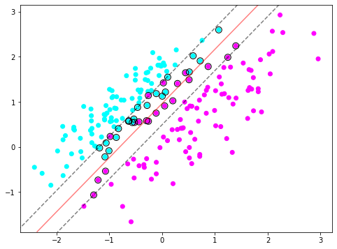

```python
# Visualization
plt.figure(figsize=(8,6))
# plot dataset
plt.scatter(x[:, 0], x[:, 1], c=y, cmap='cool')
# plot support vectors
plt.scatter(clf_3.support_vectors_[:, 0], clf_3.support_vectors_[:, 1], edgecolor='k', s=80, facecolors='none')
#plot decision boundary
decision_boundary(clf_3)
```

Obviously, it can be observed from the figure that the distribution of the dataset is linear and seems to have a 'clear boundary'. Therefore, the linear kernel is very suitable for such datasets, but in subsequent steps, we will still explore whether other kernel functions are suitable for classifying such datasets.

#### 3.1.2 Model evaluation

In this step, we will use two verification methods: Leave-One-Out CV and 10-fold CV, and compare their evaluation results. About the description of Leave-One-Out CV, please refer to chapter 1.3.

##### 3.1.2.1 Leave-One-Out CV

```python
x = ds_3.drop(['class'],axis=1).to_numpy()
y = ds_3['class'].to_numpy()
```

```python
# Create list to store the results of each evaluation
scoreList_train = []
scoreList_test = []

loo = LeaveOneOut()
for train_index, test_index in loo.split(x):
    x_train, x_test = x[train_index], x[test_index]
    y_train, y_test = y[train_index], y[test_index]

    # Train the model
    clf_loo = SVC(C=1.0, kernel='linear', gamma='scale', random_state=RANDOM_STATE)
    clf_loo.fit(x_train, y_train)

    # Evaluate the model
    score_train = clf_loo.score(x_train, y_train)
    scoreList_train.append(score_train)

    score_test = clf_loo.score(x_test, y_test)
    scoreList_test.append(score_test)

print('Mean accuracy on the training set: {:.2f}%'.format(np.mean(scoreList_train)*100))
print('Mean accuracy on the testing set: {:.2f}%'.format(np.mean(scoreList_test)*100))
```

```
Mean accuracy on the training set: 96.00%
Mean accuracy on the testing set: 96.00%
```

##### 3.1.2.2 10-fold CV

```python
x = ds_3.drop(['class'],axis=1).to_numpy()
y = ds_3['class'].to_numpy()
```

```python
# Create list to store the results of each evaluation
scoreList_train = []
scoreList_test = []

kf = KFold(n_splits=10, random_state=RANDOM_STATE, shuffle=True)
for train_index, test_index in kf.split(x):
    x_train, x_test = x[train_index], x[test_index]
    y_train, y_test = y[train_index], y[test_index]

    # Train the model
    clf_kf = SVC(C=1.0, kernel='linear', gamma='scale', random_state=RANDOM_STATE)
    clf_kf.fit(x_train, y_train)

    # Evaluate the model
    score_train = clf_kf.score(x_train, y_train)
    scoreList_train.append(score_train)

    score_test = clf_kf.score(x_test, y_test)
    scoreList_test.append(score_test)

print('Mean accuracy on the training set: {:.2f}%'.format(np.mean(scoreList_train)*100))
print('Mean accuracy on the testing set: {:.2f}%'.format(np.mean(scoreList_test)*100))
```

```
Mean accuracy on the training set: 96.00%
Mean accuracy on the testing set: 95.50%
```

##### 3.1.2.3 Summary and Explanation

For the principle and detailed analysis of leave-one-out CV and 10-fold cross-validation, please refer to chapter 2.1.2.3. Generally speaking, the evaluation result of the leave-one-out CV is more deterministic.

For the 'D3' dataset, since it has a total of 200 data, the amount of data is not very large, consider using leave-one-out CV for evaluation.

### 3.2 Pick a new kernel and 2 parameters

In this step, we will select the 'rbf' kernel and the 'poly' kernel respectively to fit the SVM model and use leave-one-out CV to evaluate their performance. We only change different kernels, other parameters keep the default.

Then, we will select the better-performing model from above, tune the parameters with 'GridSearchCV', and compare it with the linear kernel model.

#### 3.2.1 'rbf' kernel

```python
x = ds_3.drop(['class'],axis=1).to_numpy()
y = ds_3['class'].to_numpy()
```

```python
# Training model
clf_3rbf = SVC(C=1.0, kernel='rbf', gamma='scale', random_state=RANDOM_STATE)
clf_3rbf.fit(x, y)
```

```
SVC(random_state=1234)
```

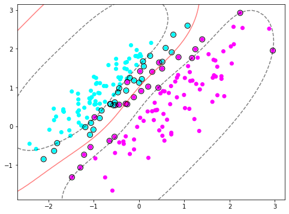

```python
# Visualization
plt.figure(figsize=(8,6))
# plot dataset
plt.scatter(x[:, 0], x[:, 1], c=y, cmap='cool')
# plot support vectors
plt.scatter(clf_3rbf.support_vectors_[:, 0], clf_3rbf.support_vectors_[:, 1], edgecolor='k', s=80, facecolors='none')
#plot decision boundary
decision_boundary(clf_3rbf)
```

```python
# Create list to store the results of each evaluation
scoreList_train = []
scoreList_test = []

loo = LeaveOneOut()
for train_index, test_index in loo.split(x):
    x_train, x_test = x[train_index], x[test_index]
    y_train, y_test = y[train_index], y[test_index]

    # Train the model
    clf_rbf_loo = SVC(C=1.0, kernel='rbf', gamma='scale', random_state=RANDOM_STATE)
    clf_rbf_loo.fit(x_train, y_train)

    # Evaluate the model
    score_train = clf_rbf_loo.score(x_train, y_train)
    scoreList_train.append(score_train)

    score_test = clf_rbf_loo.score(x_test, y_test)
    scoreList_test.append(score_test)

print('Mean accuracy on the training set: {:.2f}%'.format(np.mean(scoreList_train)*100))
print('Mean accuracy on the testing set: {:.2f}%'.format(np.mean(scoreList_test)*100))
```

```
Mean accuracy on the training set: 95.96%
Mean accuracy on the testing set: 94.50%
```

#### 3.2.2 'poly' kernel

```python
x = ds_3.drop(['class'],axis=1).to_numpy()
y = ds_3['class'].to_numpy()
```

```python
# Training model
clf_3poly = SVC(C=1.0, kernel='poly', gamma='scale', random_state=RANDOM_STATE)
clf_3poly.fit(x, y)
```

```
SVC(kernel='poly', random_state=1234)
```

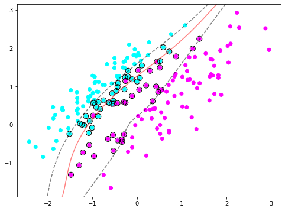

```python
# Visualization
plt.figure(figsize=(8,6))
# plot dataset
plt.scatter(x[:, 0], x[:, 1], c=y, cmap='cool')
# plot support vectors
plt.scatter(clf_3poly.support_vectors_[:, 0], clf_3poly.support_vectors_[:, 1], edgecolor='k', s=80, facecolors='none')
#plot decision boundary
decision_boundary(clf_3poly)
```

```python
# Create list to store the results of each evaluation
scoreList_train = []
scoreList_test = []

loo = LeaveOneOut()
for train_index, test_index in loo.split(x):
    x_train, x_test = x[train_index], x[test_index]
    y_train, y_test = y[train_index], y[test_index]

    # Train the model
    clf_poly_loo = SVC(C=1.0, kernel='poly', gamma='scale', random_state=RANDOM_STATE)
    clf_poly_loo.fit(x_train, y_train)

    # Evaluate the model
    score_train = clf_poly_loo.score(x_train, y_train)
    scoreList_train.append(score_train)

    score_test = clf_poly_loo.score(x_test, y_test)
    scoreList_test.append(score_test)

print('Mean accuracy on the training set: {:.2f}%'.format(np.mean(scoreList_train)*100))
print('Mean accuracy on the testing set: {:.2f}%'.format(np.mean(scoreList_test)*100))
```

```
Mean accuracy on the training set: 93.01%
Mean accuracy on the testing set: 92.00%
```

#### 3.2.3 Model selection and Explanation

From the above experimental results, it can be observed that the 'rbf' kernel performs slightly better than the 'poly' kernel, but both their model accuracy are lower than the linear kernel with default parameters. We will choose the model with the 'rbf' kernel and use 'GridSearchCV' to tune the parameters to see if it can outperform the linear kernel model.

#### 3.2.4 Parameter tuning

Due to the limitation of personal computer performance, in order to improve the efficiency of parameter tuning, we just give some values for the parameters to tune, instead of a given range.

##### 3.2.4.1 Tuning for 'rbf' kernel model

```python
x = ds_3.drop(['class'],axis=1).to_numpy()
y = ds_3['class'].to_numpy()
```

```python
# Train the model with 'GridSearchCV' to find the best parameters
clf = SVC(kernel='rbf', random_state=RANDOM_STATE)
param_grid = {'C': [0.0001, 0.001, 0.01, 0.1, 1.0, 10.0, 100.0, 1000.0], 'gamma': [0.0001, 0.001, 0.01, 0.1, 1.0, 10.0, 100.0, 1000.0]}
grid_search = GridSearchCV(estimator=clf, param_grid=param_grid, cv=10, n_jobs=-1)
grid_search.fit(x, y)
best_clf_rbf = grid_search.best_estimator_
best_clf_rbf.fit(x, y)
print(best_clf_rbf)
```

```
SVC(C=1000.0, gamma=0.01, random_state=1234)
```

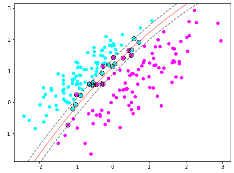

```python
# Visualization
plt.figure(figsize=(8,6))
# plot dataset
plt.scatter(x[:, 0], x[:, 1], c=y, cmap='cool')
# plot support vectors
plt.scatter(best_clf_rbf.support_vectors_[:, 0], best_clf_rbf.support_vectors_[:, 1], edgecolor='k', s=80, facecolors='none')
#plot decision boundary
decision_boundary(best_clf_rbf)
```

We use the leave-one-out CV to verify the above parameters again

```python
x = ds_3.drop(['class'],axis=1).to_numpy()
y = ds_3['class'].to_numpy()
```

```python
# Create list to store the results of each evaluation
scoreList_train = []
scoreList_test = []

loo = LeaveOneOut()
for train_index, test_index in loo.split(x):
    x_train, x_test = x[train_index], x[test_index]
    y_train, y_test = y[train_index], y[test_index]

    # Train the model
    clf = SVC(kernel='rbf', random_state=RANDOM_STATE)
    param_grid = {'C': [0.0001, 0.001, 0.01, 0.1, 1.0, 10.0, 100.0, 1000.0], 'gamma': [0.0001, 0.001, 0.01, 0.1, 1.0, 10.0, 100.0, 1000.0]}
    grid_search = GridSearchCV(estimator=clf, param_grid=param_grid, cv=10, n_jobs=-1)
    grid_search.fit(x_train, y_train)
    best_clf_rbf = grid_search.best_estimator_
    best_clf_rbf.fit(x_train, y_train)

    # Evaluate the model
    score_train = best_clf_rbf.score(x_train, y_train)
    scoreList_train.append(score_train)

    score_test = best_clf_rbf.score(x_test, y_test)
    scoreList_test.append(score_test)

print('Mean accuracy on the training set: {:.2f}%'.format(np.mean(scoreList_train)*100))
print('Mean accuracy on the testing set: {:.2f}%'.format(np.mean(scoreList_test)*100))
```

```
Mean accuracy on the training set: 95.62%
Mean accuracy on the testing set: 93.00%
```

##### 3.2.4.2 Tuning for 'linear' kernel model

```python
x = ds_3.drop(['class'],axis=1).to_numpy()
y = ds_3['class'].to_numpy()
```

```python
# Train the model with 'GridSearchCV' to find the best parameters
clf = SVC(kernel='linear', random_state=RANDOM_STATE)
param_grid = {'C': [0.0001, 0.001, 0.01, 0.1, 1.0, 10.0, 100.0, 1000.0, 10000.0]}
grid_search = GridSearchCV(estimator=clf, param_grid=param_grid, cv=10, n_jobs=-1)
grid_search.fit(x, y)
best_clf_linear = grid_search.best_estimator_
best_clf_linear.fit(x, y)
print(best_clf_linear)
```

```
SVC(C=0.1, kernel='linear', random_state=1234)
```

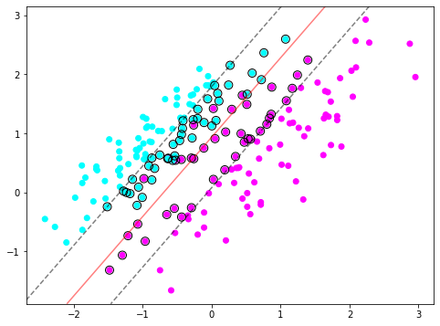

```python
# Visualization
plt.figure(figsize=(8,6))
# plot dataset
plt.scatter(x[:, 0], x[:, 1], c=y, cmap='cool')
# plot support vectors
plt.scatter(best_clf_linear.support_vectors_[:, 0], best_clf_linear.support_vectors_[:, 1], edgecolor='k', s=80, facecolors='none')
#plot decision boundary
decision_boundary(best_clf_linear)
```

We use the leave-one-out CV to verify the above parameters again

```python
x = ds_3.drop(['class'],axis=1).to_numpy()
y = ds_3['class'].to_numpy()
```

```python
# Create list to store the results of each evaluation
scoreList_train = []
scoreList_test = []

loo = LeaveOneOut()
for train_index, test_index in loo.split(x):
    x_train, x_test = x[train_index], x[test_index]
    y_train, y_test = y[train_index], y[test_index]

    # Train the model
    clf = SVC(kernel='linear', random_state=RANDOM_STATE)
    param_grid = {'C': [0.0001, 0.001, 0.01, 0.1, 1.0, 10.0, 100.0, 1000.0, 10000.0]}
    grid_search = GridSearchCV(estimator=clf, param_grid=param_grid, cv=10, n_jobs=-1)
    grid_search.fit(x_train, y_train)
    best_clf_linear = grid_search.best_estimator_
    best_clf_linear.fit(x_train, y_train)

    # Evaluate the model
    score_train = best_clf_linear.score(x_train, y_train)
    scoreList_train.append(score_train)

    score_test = best_clf_linear.score(x_test, y_test)
    scoreList_test.append(score_test)

print('Mean accuracy on the training set: {:.2f}%'.format(np.mean(scoreList_train)*100))
print('Mean accuracy on the testing set: {:.2f}%'.format(np.mean(scoreList_test)*100))
```

```
Mean accuracy on the training set: 95.68%
Mean accuracy on the testing set: 95.50%
```

### 3.3 Summary and Explanation

From the above experimental results, it can be observed that the performance of the 'rbf' kernel model after parameter tuning is slightly lower than that of the linear kernel model after parameter tuning. At the same time, the accuracies of both models are lower than the linear kernel model with default parameters, but the difference is not significant.

Since the distribution of data points also affects the final result, in the 'D3' dataset, we observed that the point distribution is already clear, and the amount of data that crosses between the two classes is very small, so whether the linear kernel or the 'rbf' kernel is used, even with the default parameters, higher accuracy can already be obtained.

In theory, the 'rbf' kernel can approximately simulate a linear kernel. In general, if the data is linearly distributed, we choose the linear kernel model; when the data distribution is ambiguous, the 'rbf' kernel model is usually the preferred solution due to its wide applicability and high performance.

For the description and detailed analysis of parameter C, please refer to chapter 1.5.

For the 'rbf' kernel model, gamma is also an important parameter that defines how much influence a single training example has. When the gamma is too large, the model is easy to overfit and the generalization ability is poor. Conversely, when the gamma is too small, the model can be made more complicated by increasing the C value.

Since the nature of machine learning is a trade-off between training accuracy and generalization ability, for the 'rbf' kernel model, the C value and the gamma value jointly affect the performance of the model.